# Sixth Week: Linear Models

House price prediction

Tara Boroushaki

2018-04-14 02:41:39

> با توجه به داده های قیمت منازل لطفا با سوالات زیر پاسخ دهید.

۱. ماتریس همبستگی متغیرهای مختلف را به دست آورده و سپس رسم نمایید. اعداد به دست آمده را با آزمون فرض معناداری همبستگی بسنجید و سپس ده متغیری که همبستگی بالاتری با قیمت دارند را مشخص نمایید.

```r
# Q1

h1=house%>%mutate(ageH=2018-YearBuilt,ageG=GarageYrBlt) %>% select_if(is.numeric) %>%
    select(ageHome=ageH,ageGarage=ageG,MSSubClass,LotFrontage,LotArea,OverallQual,OverallCond,YearRemodAdd,
           MasVnrArea,BsmtFinSF1,BsmtFinSF2,BsmtUnfSF,TotalBsmtSF,"1stFlrSF","2ndFlrSF",
           LowQualFinSF,GrLivArea,BsmtFullBath,BsmtHalfBath,FullBath,HalfBath,BedroomAbvGr,
           KitchenAbvGr,TotRmsAbvGrd,Fireplaces,GarageCars,GarageArea,WoodDeckSF,OpenPorchSF,
           EnclosedPorch,"3SsnPorch",ScreenPorch,PoolArea,MiscVal,MoSold,YrSold,SalePrice)
q1_re1=matrix(0,nrow = 37,ncol = 37)
q1_re2=matrix(0,nrow = 37,ncol = 37)
for (i in 1:37) {
  for (j in 1:37) {
    q1_re1[i,j]=cor(h1[,i],h1[,j],use="complete.obs")
    if (i==j)
      q1_re1[i,j]=0
    a=cor.test(as.data.frame(h1[,i])[,1],as.data.frame(h1[,j])[,1],na.rm=T)
    q1_re2[i,j]=as.numeric(a["p.value"])
  }
}
q1_1=as.data.frame(q1_re1)
colnames(q1_1)=names(h1)
rownames(q1_1)=names(h1)

largest=order(abs(q1_re1[,37]), decreasing=TRUE)[1:10]


for (i in 1:10) {
  writeLines(as.character(cat(cat(names(q1_1)[largest[i]]," and sale price corelation is"),q1_1[largest[i],37]))
             ,con = stdout(), sep = "\n", useBytes = FALSE)
  writeLines("\n")
}
```

```
## OverallQual  and sale price corelation is 0.7909816
##
## GrLivArea  and sale price corelation is 0.7086245
##
## GarageCars  and sale price corelation is 0.6404092
##
## GarageArea  and sale price corelation is 0.6234314
##
## TotalBsmtSF  and sale price corelation is 0.6135806
##
## 1stFlrSF  and sale price corelation is 0.6058522
##
## FullBath  and sale price corelation is 0.5606638
##
## TotRmsAbvGrd  and sale price corelation is 0.5337232
##
## ageHome  and sale price corelation is -0.5228973
##
## YearRemodAdd  and sale price corelation is 0.507101
```

۲. در یک تصویر نمودار پراکنش دو به دو ده متغیر بدست آمده به همراه قیمت را رسم نمایید و هم خطی بودن متغیرها را بررسی کنید

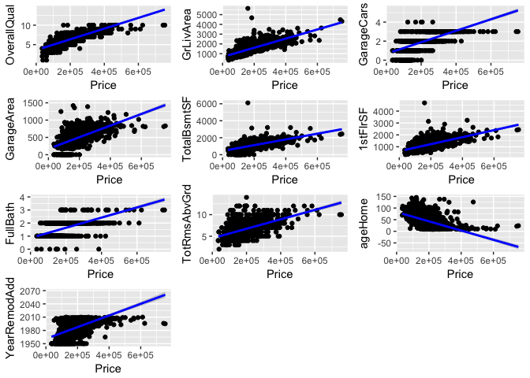

```r
# Q2

q2_data=h1[,largest]
q2_data$SalePrice=h1$SalePrice
#q2_data$YearRemodAdd=q2_data$YearRemodAdd-2000

q2_data %>%  ggplot( aes(x = SalePrice, y =.[,1])) + geom_point()+
    geom_smooth(method="lm", formula=y~x, colour = "blue")+
    ylab(names(q2_data)[1])+xlab("Price")->p2_1

q2_data %>%  ggplot( aes(x = SalePrice, y =.[,2])) + geom_point()+
  geom_smooth(method="lm", formula=y~x, colour = "blue")+
  ylab(names(q2_data)[2])+xlab("Price")->p2_2

q2_data %>%  ggplot( aes(x = SalePrice, y =.[,3])) + geom_point()+
  geom_smooth(method="lm", formula=y~x, colour = "blue")+
  ylab(names(q2_data)[3])+xlab("Price")->p2_3

q2_data %>%  ggplot( aes(x = SalePrice, y =.[,4])) + geom_point()+
  geom_smooth(method="lm", formula=y~x, colour = "blue")+
  ylab(names(q2_data)[4])+xlab("Price")->p2_4

q2_data %>%  ggplot( aes(x = SalePrice, y =.[,5])) + geom_point()+
  geom_smooth(method="lm", formula=y~x, colour = "blue")+
  ylab(names(q2_data)[5])+xlab("Price")->p2_5

q2_data %>%  ggplot( aes(x = SalePrice, y =.[,6])) + geom_point()+
  geom_smooth(method="lm", formula=y~x, colour = "blue")+
  ylab(names(q2_data)[6])+xlab("Price")->p2_6

q2_data %>%  ggplot( aes(x = SalePrice, y =.[,7])) + geom_point()+
  geom_smooth(method="lm", formula=y~x, colour = "blue")+
  ylab(names(q2_data)[7])+xlab("Price")->p2_7

q2_data %>%  ggplot( aes(x = SalePrice, y =.[,8])) + geom_point()+
  geom_smooth(method="lm", formula=y~x, colour = "blue")+
  ylab(names(q2_data)[8])+xlab("Price")->p2_8

q2_data %>%  ggplot( aes(x = SalePrice, y =.[,9])) + geom_point()+
  geom_smooth(method="lm", formula=y~x, colour = "blue")+
  ylab(names(q2_data)[9])+xlab("Price")->p2_9

q2_data %>%  ggplot( aes(x = SalePrice, y =.[,10])) + geom_point()+
  geom_smooth(method="lm", formula=y~x, colour = "blue")+
  ylab(names(q2_data)[10])+xlab("Price")->p2_10

grid.arrange(p2_1, p2_2, p2_3, p2_4,p2_5, p2_6, p2_7, p2_8, p2_9, p2_10, ncol=3)
```

۳. یک مدل خطی بر اساس ده متغیر برای پیش بینی قیمت برازش دهید. و سپس خلاصه نتایج مدل را به دست آورید.

```r
fit_ = lm(SalePrice ~ OverallQual+GrLivArea+GarageCars+GarageArea+TotalBsmtSF+
           FullBath+TotRmsAbvGrd+ageHome+YearRemodAdd, data = q2_data)
summary(fit_)
```

```
##
## Call:
## lm(formula = SalePrice ~ OverallQual + GrLivArea + GarageCars +
##     GarageArea + TotalBsmtSF + FullBath + TotRmsAbvGrd + ageHome +
##     YearRemodAdd, data = q2_data)
##
## Residuals:
##     Min      1Q  Median      3Q     Max
## -496297  -19487   -2241   15581  289543
##
## Coefficients:
##                Estimate Std. Error t value Pr(>|t|)
## (Intercept)  -6.382e+05  1.257e+05  -5.075 4.37e-07 ***
## OverallQual   1.923e+04  1.186e+03  16.216  < 2e-16 ***
## GrLivArea     5.372e+01  4.158e+00  12.920  < 2e-16 ***
## GarageCars    1.053e+04  3.052e+03   3.451 0.000575 ***
## GarageArea    1.693e+01  1.031e+01   1.641 0.101020
## TotalBsmtSF   2.899e+01  2.902e+00   9.992  < 2e-16 ***
## FullBath     -6.408e+03  2.686e+03  -2.386 0.017159 *
## TotRmsAbvGrd  4.175e+01  1.122e+03   0.037 0.970317
## ageHome      -2.581e+02  5.035e+01  -5.125 3.37e-07 ***
## YearRemodAdd  2.947e+02  6.379e+01   4.620 4.19e-06 ***
## ---
## Signif. codes:  0 '***' 0.001 '**' 0.01 '*' 0.05 '.' 0.1 ' ' 1
##
## Residual standard error: 38020 on 1450 degrees of freedom
## Multiple R-squared:  0.7724, Adjusted R-squared:  0.771
## F-statistic: 546.8 on 9 and 1450 DF,  p-value: < 2.2e-16
```

۴. نمودار قیمت واقعی و قیمت پیش بینی را رسم نمایید و خوب بودن مدل را ارزیابی کنید.

هر چه داده ها به خط قرمز که ۴۵ درجه شیب دارند نزدیک باشند بهتر پیش بینی شده اند. هرچه خط سبز به خط قرمز نزدیک تر باشد نشان میدهد که پیش بینی به طور کلی بهتر بوده است.

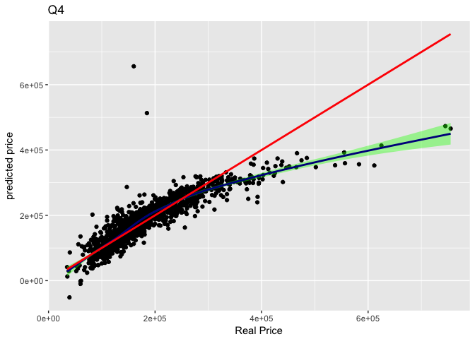

```r
q2_data$priceGuess=predict(fit_, q2_data)



p <- ggplot() +
  # blue plot
  geom_point(data=q2_data, aes(x = SalePrice, y =priceGuess)) +
  geom_smooth(data=q2_data, aes(x = SalePrice, y =priceGuess), fill="green",
              colour="darkblue", size=1)+
  geom_smooth(data=q2_data, aes(x = SalePrice, y =SalePrice), fill="red",
              colour="red", size=1)+
  ylab("predicted price")+xlab("Real Price")+ggtitle("Q4")

p
```

۵. مقدار R-squared مدل را به دست آورید. آیا بر اساس این کمیت مدل به خوبی به داده ها برازش داده شده است؟ کمیت F-statistic را در خلاصه مدل تفسیر نمایید.

هر چه R2 به یک نزدیک تر باشد نشان می دهد که مدل خطی بهتر عمل کرده است. ۰.۷۷ هم مقدار نسبتا خوبی است. F-statistic فرض صفرش ، صفر بودن تمامی ضرایب است. یعنی در فرض صفر هیچ یک از متغیر ها تاثیری در قیمت ندارند. هرچه مقدار F-statistic بیشتر باشد نشان میدهد تاثیر بیشتر بوده است. F-statistic در اینجا مقدار خوبی دارد.

The computed F-statistic suggests that the r-square produced by the model is statistically significant at alpha = 0.01.

```r
summary(fit_)
```

```
##
## Call:
## lm(formula = SalePrice ~ OverallQual + GrLivArea + GarageCars +
##     GarageArea + TotalBsmtSF + FullBath + TotRmsAbvGrd + ageHome +
##     YearRemodAdd, data = q2_data)
##
## Residuals:
##     Min      1Q  Median      3Q     Max
## -496297  -19487   -2241   15581  289543
##
## Coefficients:
##                Estimate Std. Error t value Pr(>|t|)
## (Intercept)  -6.382e+05  1.257e+05  -5.075 4.37e-07 ***
## OverallQual   1.923e+04  1.186e+03  16.216  < 2e-16 ***
## GrLivArea     5.372e+01  4.158e+00  12.920  < 2e-16 ***
## GarageCars    1.053e+04  3.052e+03   3.451 0.000575 ***
## GarageArea    1.693e+01  1.031e+01   1.641 0.101020
## TotalBsmtSF   2.899e+01  2.902e+00   9.992  < 2e-16 ***
## FullBath     -6.408e+03  2.686e+03  -2.386 0.017159 *
## TotRmsAbvGrd  4.175e+01  1.122e+03   0.037 0.970317
## ageHome      -2.581e+02  5.035e+01  -5.125 3.37e-07 ***
## YearRemodAdd  2.947e+02  6.379e+01   4.620 4.19e-06 ***
## ---
## Signif. codes:  0 '***' 0.001 '**' 0.01 '*' 0.05 '.' 0.1 ' ' 1
##
## Residual standard error: 38020 on 1450 degrees of freedom
## Multiple R-squared:  0.7724, Adjusted R-squared:  0.771
## F-statistic: 546.8 on 9 and 1450 DF,  p-value: < 2.2e-16
```

۶. بر اساس p-value سطح معناداری ضرایب تصمیم بگیرید که چه متغیرهایی در مدل سازی استفاده شود. بر اساس متغیرهای جدید دوباره مدل سازی کنید و نتایج رو گزارش دهید.

میزان R2 کمی کمتر شده. کاهش R2 بسیار کم است که نشان میدهد متغیر های حذف شده تاثیر کمی داشته اند.F-statistic افزایش یافته، که نشان میدهد این بار متغیر های انتخاب شده به طور متوسط تاثیر بیشتری روی قیمت دارند.

مدل سازی کمی ساده تر شده ولی نتایج تغییرات خاصی در نمودار و نتایج دیده نمی شود.

```r
# Q6

q6_data=q2_data

fit_6 = lm(SalePrice ~ OverallQual+GrLivArea+GarageCars+TotalBsmtSF+
            ageHome+YearRemodAdd, data = q6_data)
summary(fit_6)
```

```
##
## Call:
## lm(formula = SalePrice ~ OverallQual + GrLivArea + GarageCars +
##     TotalBsmtSF + ageHome + YearRemodAdd, data = q6_data)
##
## Residuals:
##     Min      1Q  Median      3Q     Max
## -477106  -19737   -2015   16452  290098
##
## Coefficients:
##                Estimate Std. Error t value Pr(>|t|)
## (Intercept)  -6.071e+05  1.254e+05  -4.842 1.42e-06 ***
## OverallQual   1.912e+04  1.186e+03  16.123  < 2e-16 ***
## GrLivArea     5.036e+01  2.551e+00  19.743  < 2e-16 ***
## GarageCars    1.439e+04  1.813e+03   7.939 4.03e-15 ***
## TotalBsmtSF   3.086e+01  2.811e+00  10.979  < 2e-16 ***
## ageHome      -2.211e+02  4.802e+01  -4.605 4.49e-06 ***
## YearRemodAdd  2.757e+02  6.353e+01   4.340 1.52e-05 ***
## ---
## Signif. codes:  0 '***' 0.001 '**' 0.01 '*' 0.05 '.' 0.1 ' ' 1
##
## Residual standard error: 38100 on 1453 degrees of freedom
## Multiple R-squared:  0.7709, Adjusted R-squared:   0.77
## F-statistic:   815 on 6 and 1453 DF,  p-value: < 2.2e-16
```

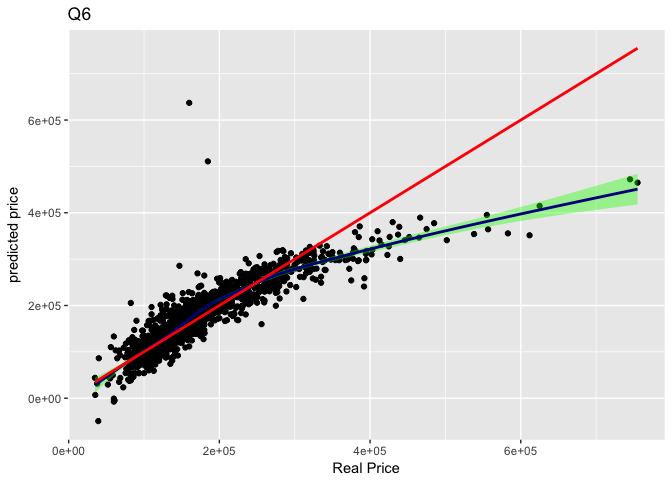

```r
q6_data$priceGuess=predict(fit_6, q6_data)

#R-squared
R2_6 <- 1 - (sum((q6_data$SalePrice-q6_data$priceGuess )^2)/sum((q6_data$SalePrice-mean(q6_data$SalePrice))^2))
#RMSE
my_RMSE_6<-sqrt(mean((q6_data$priceGuess -q6_data$SalePrice)^2))

p6 <- ggplot() +
  # blue plot
  geom_point(data=q6_data, aes(x = SalePrice, y =priceGuess)) +
  geom_smooth(data=q6_data, aes(x = SalePrice, y =priceGuess), fill="green",
              colour="darkblue", size=1)+
  geom_smooth(data=q6_data, aes(x = SalePrice, y =SalePrice), fill="red",
              colour="red", size=1)+
  ylab("predicted price")+xlab("Real Price")+ggtitle("Q6")

p6
```

۷. مدل خود را بر اساس باقی مانده نقص یابی کنید. سه محک normality, independance, Constant Variance را در نقص یابی خود در نظر بگیرید.

Normality of residuals:

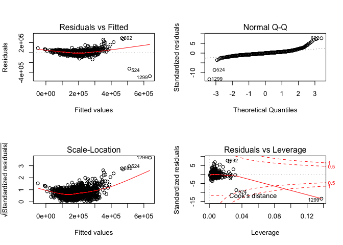

```r
#Normality of residuals
par(mfrow=c(2,2))
plot(fit_6)
```

Constant Variance:

(Homoscedasticity of residuals or equal variance)

From the first plot (top-left), as the fitted values along x increase, the residuals decrease and then increase. This pattern is indicated by the red line, which should be approximately flat if the disturbances are homoscedastic.In this question, there is a definite pattern noticed. So, there is heteroscedasticity.

independance:

When the residuals are autocorrelated, it means that the current value is dependent of the previous (historic) values and that there is a definite unexplained pattern in the Y variable that shows up in the disturbances. In the first method, If the residuals are autocorrelated, the correlation (Y-axis) from the immediate next line onwards will be above the dashed blue line (significance level), so the plot indicate that the residuals are not correlated. In the second method, With a p-value > 0.05 , we cannot reject the null hypothesis which means there is not a definite pattern in the residuals.

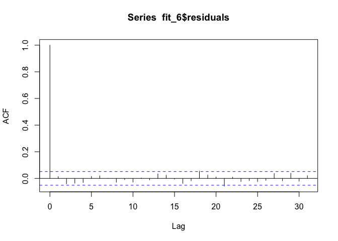

```r
# method 1
acf(fit_6$residuals)
```

```r
# method 2
lawstat::runs.test(fit_6$residuals)
```

```
##
##  Runs Test - Two sided
##
## data:  fit_6$residuals
## Standardized Runs Statistic = -0.99485, p-value = 0.3198
```

۸. داده ها را به پنج قسمت تقسیم کنید. بر اساس چهار قسمت مدل خطی را بسازید و صحت مدل را برای یک قسمت باقی مانده را تست کنید. خطای پیش بینی شما چقدر است؟

در این حالت چون داده های تست در فرایند پیدا کردن ضرایب نقش نداشته اند، R2 و mean squre نشان می دهند که خطا به نسبت قسمت ۶ افزایش یافته است.

```r
# Q8
length=dim(h1)[1]*0.8
train_8=h1[1:length,]
test_8=h1[(length+1):dim(h1)[1],]

fit_8 = lm(SalePrice ~ OverallQual+GrLivArea+GarageCars+TotalBsmtSF+
             ageHome+YearRemodAdd, data = train_8)
summary(fit_8)
```

```
##
## Call:
## lm(formula = SalePrice ~ OverallQual + GrLivArea + GarageCars +
##     TotalBsmtSF + ageHome + YearRemodAdd, data = train_8)
##
## Residuals:
##     Min      1Q  Median      3Q     Max
## -355459  -19653   -1359   16219  271020
##
## Coefficients:
##                Estimate Std. Error t value Pr(>|t|)
## (Intercept)  -7.240e+05  1.302e+05  -5.561 3.32e-08 ***
## OverallQual   1.649e+04  1.251e+03  13.175  < 2e-16 ***
## GrLivArea     5.659e+01  2.739e+00  20.660  < 2e-16 ***
## GarageCars    1.153e+04  1.959e+03   5.883 5.26e-09 ***
## TotalBsmtSF   4.090e+01  3.038e+00  13.462  < 2e-16 ***
## ageHome      -2.393e+02  4.945e+01  -4.840 1.48e-06 ***
## YearRemodAdd  3.359e+02  6.605e+01   5.085 4.27e-07 ***
## ---
## Signif. codes:  0 '***' 0.001 '**' 0.01 '*' 0.05 '.' 0.1 ' ' 1
##
## Residual standard error: 35410 on 1161 degrees of freedom
## Multiple R-squared:  0.7992, Adjusted R-squared:  0.7981
## F-statistic: 769.9 on 6 and 1161 DF,  p-value: < 2.2e-16
```

```r
test_8$priceGuess=predict(fit_8, test_8)

#R-squared
R2 <- 1 - (sum((test_8$SalePrice-test_8$priceGuess )^2)/sum((test_8$SalePrice-mean(test_8$SalePrice))^2))
R2
```

```
## [1] 0.648071
```

```r
#RMSE
my_RMSE<-sqrt(mean((test_8$priceGuess -test_8$SalePrice)^2))
my_RMSE
```

```
## [1] 48577.91
```

۹. آیا قیمت ربط غیر خطی با یکی از ده متغیر استفاده شده دارد؟ بر اساس دستاوردهای خود مدل را بهتر نمایید.

وقتی ضرایب رابطه ی غیر خطی را پیدا میکنیم و قیمت خانه ها را پیش یبینی میکنیم بر اساس R2 و mean Square واضح است که خطا به نسبت قسمت ۶ کاهش یافته است.

```r
# Q9

fit_9 = lm(SalePrice ~ OverallQual*GrLivArea*GarageCars*TotalBsmtSF*ageHome*YearRemodAdd, data = q6_data)
summary(fit_9)
```

```
##
## Call:
## lm(formula = SalePrice ~ OverallQual * GrLivArea * GarageCars *
##     TotalBsmtSF * ageHome * YearRemodAdd, data = q6_data)
##
## Residuals:
##     Min      1Q  Median      3Q     Max
## -164485  -13624    -182   12070  160652
##
## Coefficients:
##                                                                     Estimate
## (Intercept)                                                        8.177e+07
## OverallQual                                                       -1.508e+07
## GrLivArea                                                         -5.288e+04
## GarageCars                                                        -7.172e+07
## TotalBsmtSF                                                       -6.078e+04
## ageHome                                                           -1.133e+06
## YearRemodAdd                                                      -4.113e+04
## OverallQual:GrLivArea                                              9.772e+03
## OverallQual:GarageCars                                             1.199e+07
## GrLivArea:GarageCars                                               4.098e+04
## OverallQual:TotalBsmtSF                                            1.107e+04
## GrLivArea:TotalBsmtSF                                              3.735e+01
## GarageCars:TotalBsmtSF                                             6.531e+04
## OverallQual:ageHome                                                2.092e+05
## GrLivArea:ageHome                                                  7.454e+02
## GarageCars:ageHome                                                 9.127e+05
## TotalBsmtSF:ageHome                                                9.928e+02
## OverallQual:YearRemodAdd                                           7.578e+03
## GrLivArea:YearRemodAdd                                             2.659e+01
## GarageCars:YearRemodAdd                                            3.610e+04
## TotalBsmtSF:YearRemodAdd                                           3.061e+01
## ageHome:YearRemodAdd                                               5.701e+02
## OverallQual:GrLivArea:GarageCars                                  -6.803e+03
## OverallQual:GrLivArea:TotalBsmtSF                                 -6.761e+00
## OverallQual:GarageCars:TotalBsmtSF                                -1.057e+04
## GrLivArea:GarageCars:TotalBsmtSF                                  -3.544e+01
## OverallQual:GrLivArea:ageHome                                     -1.373e+02
## OverallQual:GarageCars:ageHome                                    -1.512e+05
## GrLivArea:GarageCars:ageHome                                      -5.188e+02
```

[output cut: 286 more lines]

```
## GrLivArea:TotalBsmtSF:ageHome:YearRemodAdd                        ***
## GarageCars:TotalBsmtSF:ageHome:YearRemodAdd                       ***
## OverallQual:GrLivArea:GarageCars:TotalBsmtSF:ageHome              ***
## OverallQual:GrLivArea:GarageCars:TotalBsmtSF:YearRemodAdd         ***
## OverallQual:GrLivArea:GarageCars:ageHome:YearRemodAdd             ***
## OverallQual:GrLivArea:TotalBsmtSF:ageHome:YearRemodAdd            ***
## OverallQual:GarageCars:TotalBsmtSF:ageHome:YearRemodAdd           ***
## GrLivArea:GarageCars:TotalBsmtSF:ageHome:YearRemodAdd             ***
## OverallQual:GrLivArea:GarageCars:TotalBsmtSF:ageHome:YearRemodAdd ***
## ---
## Signif. codes:  0 '***' 0.001 '**' 0.01 '*' 0.05 '.' 0.1 ' ' 1
##
## Residual standard error: 26390 on 1396 degrees of freedom
## Multiple R-squared:  0.8944, Adjusted R-squared:  0.8897
## F-statistic: 187.7 on 63 and 1396 DF,  p-value: < 2.2e-16
```

```r
q9_data=q6_data
q9_data$priceGuess=predict(fit_9, q9_data)

#R-squared
R2_9 <- 1 - (sum((q9_data$SalePrice-q9_data$priceGuess )^2)/sum((q9_data$SalePrice-mean(q9_data$SalePrice))^2))
#RMSE
my_RMSE_9<-sqrt(mean((q9_data$priceGuess -q9_data$SalePrice)^2))


##
R2_6
```

```
## [1] 0.7709311
```

```r
R2_9
```

```
## [1] 0.8944296
```

```r
my_RMSE_6
```

```
## [1] 38009.07
```

```r
my_RMSE_9
```

```
## [1] 25803.3
```

```r
##
```

۱۰. بر اساس مدل نهایی به دست آمده نتایج پیش بینی خود را بر روی test.csv به دست آورید و در سایت kaggle در مسابقه House Prices: Advanced Regression Techniques بارگذاری نمایید. سپس لینک رتبه و عدد آن را ضمیمه تمرین کنید.

```r
test=read_csv("/Users/Apple/Documents/TaraFiles/University/term 8/Data Analysis/week_6/house/test.csv")
test_data=test%>%mutate(ageHome=2018-YearBuilt)%>%select( OverallQual,GrLivArea,GarageCars,TotalBsmtSF,ageHome,YearRemodAdd,Id)
test$priceGuess=predict(fit_9, test_data)

test10=test%>%select(Id,SalePrice=priceGuess)

na_replace=mean(test10$SalePrice,na.rm = T)
test10$SalePrice[661]=na_replace
test10$SalePrice[1117]=na_replace
#write_csv(test10,"/Users/Apple/Documents/TaraFiles/University/term 8/Data Analysis/week_6/house/testResult.csv")
```

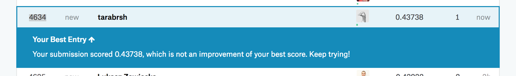